# Marker use analysis

Matt Jaquiery (matt.jaquiery@psy.ox.ac.uk)

August 2019

## Introduction

Marker use study v0.0.1 provides the same markers as the datesStudy studies, but removes the by-decade labelling on the timeline. The other versions return the timeline labels but use a variety of different marker widths.

## Load data

exclude <- list( maxAttnCheckFails = 0 # pass all attn checks )

skipLoadData <- F

# source(/01 Load Data.R)

source(/02 Exclusions.R)

### Exclusions

Exclusions happen in the following order:

- Exclude participants failing attention checks and remove their trials

The numbers excluded for these reasons (participants can be excluded for multiple reasons):

tmp <- suppressWarnings(left_join(exclusions, okayIds, by = ))

tmp$condition <- factor(tmp$condition, labels = c(_AgrFirst, _AccFirst, ¬fb_AgrFirst, ¬fb_AccFirst))

table(tmp$excluded, tmp$condition)

```
                               fb_AgrFirst fb_AccFirst Â¬fb_AgrFirst Â¬fb_AccFirst
  attnCheckWidth                         0           1            1            0
  attnCheckYear                          0           1            3            2
  attnCheckYear attnCheckWidth           1           1            1            0
  FALSE                                 28          23           18           20
```

# Key outcome

The key outcome is marker usage on the first decision. We are hoping for a relatively even balance between options, perhaps with a slight preference for the middle option.

PP$studyVersion <- sapply(PP$pid, function(x) unique(AdvisedTrial$studyVersion[AdvisedTrial$pid %in% x]))

for (v in unique(PP$studyVersion)) {

tmp <- PP[PP$studyVersion == v & !is.na(PP$responseMarker) & PP$decision == , ] tmp$responseMarker <- factor(tmp$responseMarker, levels = levels(tmp$responseMarker)[order( as.integer(levels(tmp$responseMarker)))])

print( ggplot(tmp, aes(x = responseMarker, y = proportion)) + geom_violin(alpha = .25, colour = NA, fill = 75) + geom_line(alpha = 2/length(unique(PP$pid)), aes(group = pid), size = 1.25) + geom_point(aes(colour = pid), size = 2) + stat_summary(geom = , fun.y = mean, aes(group = 1, linetype = ), size = 1.5) + scale_linetype_manual(values = c()) + scale_colour_discrete(guide = ) + labs(x = marker width (years), y = (marker used), title = paste(version, v)) ) }

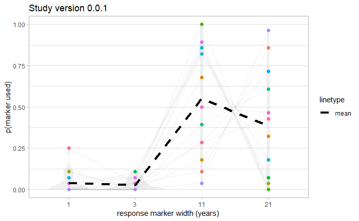

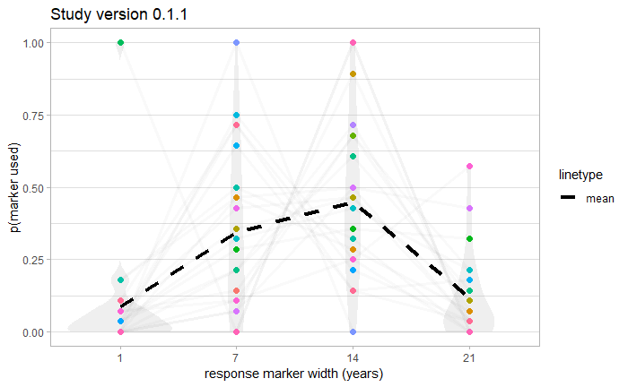

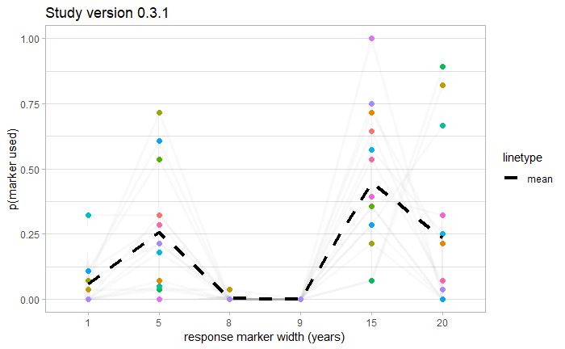

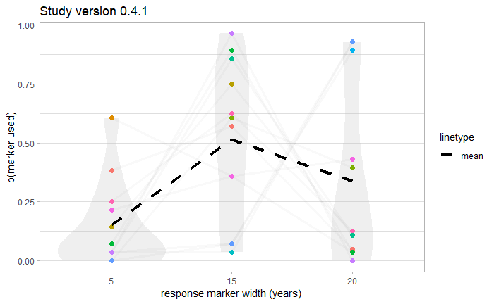

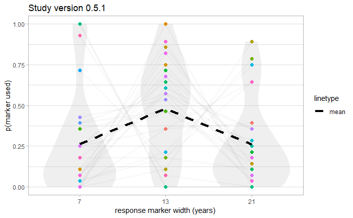

## Summary

Marker widths of 7/13/21 seem to give about the desired pattern, with high- and low-confidence responses equally frequent, and with medium-confidence responses slightly more frequent. This pattern emerges in aggregate, however, and is not clearly demonstrated by the majority of participants. Indeed, very few individual participants show this pattern at all: most participants have a clear favourite width and use the other markers sparingly.

## Credits

### Acknowledgements

Thanks as always to Nick Yeung and the other folks at the [ACC Lab](https://www.psy.ox.ac.uk/research/attention-cognitive-control-lab).

### R Packages

kable(out)

| Package | Citations |
| --- | --- |
| base | R Core Team (2018). R: A language and environment for statistical computing. R Foundation for Statistical Computing, Vienna, Austria. URL https://www.R-project.org/. |
| beepr | Rasmus B攼㸵攼㸵th (2018). beepr: Easily Play Notification Sounds on any Platform. R package version 1.3. https://CRAN.R-project.org/package=beepr |
| knitr | Yihui Xie (2019). knitr: A General-Purpose Package for Dynamic Report Generation in R. R package version 1.23. Yihui Xie (2015) Dynamic Documents with R and knitr. 2nd edition. Chapman and Hall/CRC. I… |
| ez | Michael A. Lawrence (2016). ez: Easy Analysis and Visualization of Factorial Experiments. R package version 4.4-0. https://CRAN.R-project.org/package=ez |
| BANOVA |  |
| BayesFactor | Richard D. Morey and Jeffrey N. Rouder (2018). BayesFactor: Computation of Bayes Factors for Common Designs. R package version 0.9.12-4.2. https://CRAN.R-project.org/package=BayesFactor |
| Matrix | Douglas Bates and Martin Maechler (2018). Matrix: Sparse and Dense Matrix Classes and Methods. R package version 1.2-14. https://CRAN.R-project.org/package=Matrix |
| coda | Martyn Plummer, Nicky Best, Kate Cowles and Karen Vines (2006). CODA: Convergence Diagnosis and Output Analysis for MCMC, R News, vol 6, 7-11 |
| lsr | Navarro, D. J. (2015) Learning statistics with R: A tutorial for psychology students and other beginners. (Version 0.5) University of Adelaide. Adelaide, Australia |
| curl | Jeroen Ooms (2018). curl: A Modern and Flexible Web Client for R. R package version 3.2. https://CRAN.R-project.org/package=curl |
| forcats | Hadley Wickham (2018). forcats: Tools for Working with Categorical Variables (Factors). R package version 0.3.0. https://CRAN.R-project.org/package=forcats |
| stringr | Hadley Wickham (2019). stringr: Simple, Consistent Wrappers for Common String Operations. R package version 1.4.0. https://CRAN.R-project.org/package=stringr |
| purrr | Lionel Henry and Hadley Wickham (2018). purrr: Functional Programming Tools. R package version 0.2.5. https://CRAN.R-project.org/package=purrr |
| readr | Hadley Wickham, Jim Hester and Romain Francois (2017). readr: Read Rectangular Text Data. R package version 1.1.1. https://CRAN.R-project.org/package=readr |
| tidyr | Hadley Wickham and Lionel Henry (2018). tidyr: Easily Tidy Data with 㤼㸱spread()㤼㸲 and 㤼㸱gather()㤼㸲 Functions. R package version 0.8.1. https://CRAN.R-project.org/package=tidyr |
| tibble | Kirill M昼㹣ller and Hadley Wickham (2019). tibble: Simple Data Frames. R package version 2.1.3. https://CRAN.R-project.org/package=tibble |
| ggplot2 | H. Wickham. ggplot2: Elegant Graphics for Data Analysis. Springer-Verlag New York, 2016. |
| tidyverse | Hadley Wickham (2017). tidyverse: Easily Install and Load the 㤼㸱Tidyverse㤼㸲. R package version 1.2.1. https://CRAN.R-project.org/package=tidyverse |
| testthat | Hadley Wickham. testthat: Get Started with Testing. The R Journal, vol.愼㸰3, no. 1, pp.愼㸰5㤼㸶10, 2011 |
| prettyMD | Matt Jaquiery (2018). prettyMD: Format Test Outputs with Markdown. R package version 0.1.0. |
| dplyr | Hadley Wickham, Romain Fran攼㸷ois, Lionel Henry and Kirill M昼㹣ller (2019). dplyr: A Grammar of Data Manipulation. R package version 0.8.3. https://CRAN.R-project.org/package=dplyr |
| binaryLogic | Daniel D昼㸶rrh昼㸶fer (2017). binaryLogic: Binary Logic. R package version 0.3.9. https://CRAN.R-project.org/package=binaryLogic |

### Funding

Matt Jaquiery is funded by a studentship from the [Medical Research Council](https://mrc.ukri.org/) (reference 1943590) and the University of Oxford [Department of Experimental Psychology](https://www.psy.ox.ac.uk/) (reference 17/18_MSD_661552).

### Technical details

`r`r cat(paste(‘Time stamp:’, Sys.time(), ‘’))

```
Time stamp: 2019-08-28 11:14:08
```

`r`r cat(‘Runtime ’)

```
Runtime
```

`r`r proc.time()

```
   user  system elapsed
 155.84    8.29  972.35
```